# Kyphosis Disease Classification

## 1. Introduction

Our objective is to classify whether our patient had kyphosis after the spinal surgery. The dataset contains 3 predictors and 1 target variable. The dataset was downloaded from (https://www.kaggle.com/abbasit/kyphosis-dataset)

- Age: in months
- Number: the number of vertebrae involved
- Start: the number of the first (topmost) vertebra operated on.
- Kyphosis: our target variable. when level = 'present', a kyphosis was present after the surgery. level = 'absent' means otherwise.

## 2. Data & Libaray

Our dataset is consist of 81 observations

```python
import pandas as pd
import numpy as np
import matplotlib.pyplot as plt
import seaborn as sns
%matplotlib inline
```

```python
df = pd.read_csv("kyphosis.csv")
print(df.shape)
print(df.head(5))
```

```
(81, 4)
  Kyphosis  Age  Number  Start
0   absent   71       3      5
1   absent  158       3     14
2  present  128       4      5
3   absent    2       5      1
4   absent    1       4     15
```

Range for Age, Number, Start variables varies. However, since we are using Decision Tress algorithm, we do not need data scaling/normalization here.

```python
df.describe()
```

|  | Age | Number | Start |
| --- | --- | --- | --- |
| count | 81.000000 | 81.000000 | 81.000000 |
| mean | 83.654321 | 4.049383 | 11.493827 |
| std | 58.104251 | 1.619423 | 4.883962 |
| min | 1.000000 | 2.000000 | 1.000000 |
| 25% | 26.000000 | 3.000000 | 9.000000 |
| 50% | 87.000000 | 4.000000 | 13.000000 |
| 75% | 130.000000 | 5.000000 | 16.000000 |
| max | 206.000000 | 10.000000 | 18.000000 |

## 3. Explanatory Analysis & Data Cleaning

```python
df.Kyphosis.value_counts()
```

```
absent     64
present    17
Name: Kyphosis, dtype: int64
```

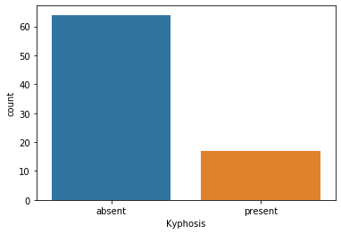

```python
sns.countplot(df['Kyphosis'], label = "Counts")
```

We are going to transform categorical values from target variable into 0/1. That is, 'absent' turned into 0 and 'present' turned into 1 after applying LabelEncoder.

```python
from sklearn.preprocessing import LabelEncoder, OneHotEncoder
LabelEncoder_y = LabelEncoder()
df['Kyphosis'] = LabelEncoder_y.fit_transform(df['Kyphosis'])
```

```python
df.Kyphosis.value_counts()
```

```
0    64
1    17
Name: Kyphosis, dtype: int64
```

Next we look into correlations between variables. There seem to be negative correlation between Number and Start variable. Since Decision Tree is non-parametric algorithm and it does not make assumptions on relationship between features, the trend we see won't impact on model performance.

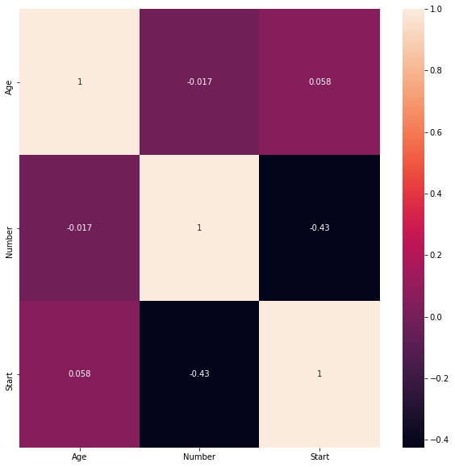

```python
plt.figure(figsize=(10,10))
sns.heatmap(df[['Age','Number','Start']].corr(), annot=True)
```

From the pair chart, we can see that mean value for Kyphosis Present and Kyphosis Absent are quite similar, in case of Age and Number. Our task can be challenging.

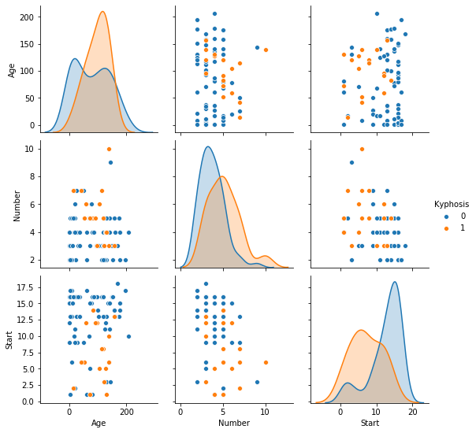

```python
sns.pairplot(df, hue='Kyphosis', vars = ['Age', 'Number', 'Start'])
```

## 4. Decision Tree, Random Forest - Training / Optimizing

We are going to train our model using two algorithms. We expect the Random Forest will throw a better result since the algorithm overcomes Decision Tree's overfitting problem by taking averages of multiple predictions from multiple random decision trees.

```python
X = df.drop(['Kyphosis'],axis=1)
y = df['Kyphosis']
```

```python
from sklearn.model_selection import train_test_split
```

```python
X_train, X_test, y_train, y_test = train_test_split(X, y, test_size=0.3)
```

```python
print("X_train", X_train.shape)
print("y_train",y_train.shape)
print("X_test",X_test.shape)
print("y_test",y_test.shape)
```

```
X_train (56, 3)
y_train (56,)
X_test (25, 3)
y_test (25,)
```

We fit two models using DecisionTreeClassifier() and RandomForestClassifier. By setting n_estimators=150, we are pruning 150 trees and the result will take majority vote.

```python
from sklearn.tree import DecisionTreeClassifier
decision_tree = DecisionTreeClassifier()
decision_tree.fit(X_train,y_train)
```

```
DecisionTreeClassifier(ccp_alpha=0.0, class_weight=None, criterion='gini',
                       max_depth=None, max_features=None, max_leaf_nodes=None,
                       min_impurity_decrease=0.0, min_impurity_split=None,
                       min_samples_leaf=1, min_samples_split=2,
                       min_weight_fraction_leaf=0.0, presort='deprecated',
                       random_state=None, splitter='best')
```

```python
from sklearn.ensemble import RandomForestClassifier
RandomForest = RandomForestClassifier(n_estimators=150)
RandomForest.fit(X_train, y_train)
```

```
RandomForestClassifier(bootstrap=True, ccp_alpha=0.0, class_weight=None,
                       criterion='gini', max_depth=None, max_features='auto',
                       max_leaf_nodes=None, max_samples=None,
                       min_impurity_decrease=0.0, min_impurity_split=None,
                       min_samples_leaf=1, min_samples_split=2,
                       min_weight_fraction_leaf=0.0, n_estimators=150,
                       n_jobs=None, oob_score=False, random_state=None,
                       verbose=0, warm_start=False)
```

With 'DecisionTreeClassifier' object, we can obtain what we call feature importance (= significance of attribute), and get to know which variable has the highest impact when it comes to training. Feature importance is calculated based on how much each feature contributes to decreasing the weighted impurity.

```python
feature_importances = pd.DataFrame(decision_tree.feature_importances_,
                                   index = X_train.columns,
                                    columns=['importance']).sort_values('importance',ascending=False)
```

```python
feature_importances
```

|  | importance |
| --- | --- |
| Start | 0.485735 |
| Age | 0.462962 |
| Number | 0.051304 |

## 5. Decision Tree, Random Forest - Evaluating

For training data set, we didn't misclassify any sample with training data, with two algorithms.

```python
from sklearn.metrics import classification_report, confusion_matrix
```

```python
y_predict_train_tree = decision_tree.predict(X_train)
y_predict_train_forest = RandomForest.predict(X_train)
```

```python
cm = confusion_matrix(y_train, y_predict_train_tree)
cm2 = confusion_matrix(y_train, y_predict_train_forest)
```

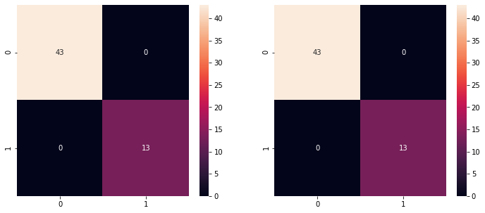

```python
plt.figure(figsize=(12,5))
plt.subplot(1,2,1)
sns.heatmap(cm, annot=True)
plt.subplot(1,2,2)
sns.heatmap(cm2, annot=True)
```

```python
print(classification_report(y_train, y_predict_train_tree))
print(classification_report(y_train, y_predict_train_forest))
```

```
              precision    recall  f1-score   support

           0       1.00      1.00      1.00        43
           1       1.00      1.00      1.00        13

    accuracy                           1.00        56
   macro avg       1.00      1.00      1.00        56
weighted avg       1.00      1.00      1.00        56

              precision    recall  f1-score   support

           0       1.00      1.00      1.00        43
           1       1.00      1.00      1.00        13

    accuracy                           1.00        56
   macro avg       1.00      1.00      1.00        56
weighted avg       1.00      1.00      1.00        56
```

When applied both model on testing data set, Decision tree showed 79% F1 score vs. Random Forest showed 84%.

```python
y_predict_test_tree = decision_tree.predict(X_test)
y_predict_test_forest = RandomForest.predict(X_test)
```

```python
cm3 = confusion_matrix(y_test, y_predict_test_tree)
cm4 = confusion_matrix(y_test, y_predict_test_forest)
```

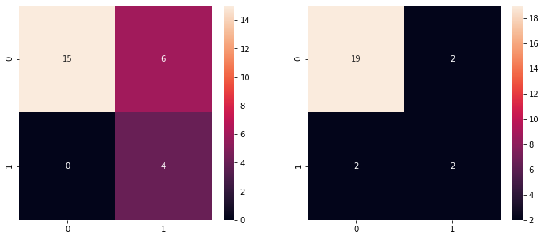

```python
plt.figure(figsize=(12,5))
plt.subplot(1,2,1)
sns.heatmap(cm3, annot=True)
plt.subplot(1,2,2)
sns.heatmap(cm4, annot=True)
```

```python
print(classification_report(y_test, y_predict_test_tree))
print(classification_report(y_test, y_predict_test_forest))
```

```
              precision    recall  f1-score   support

           0       1.00      0.71      0.83        21
           1       0.40      1.00      0.57         4

    accuracy                           0.76        25
   macro avg       0.70      0.86      0.70        25
weighted avg       0.90      0.76      0.79        25

              precision    recall  f1-score   support

           0       0.90      0.90      0.90        21
           1       0.50      0.50      0.50         4

    accuracy                           0.84        25
   macro avg       0.70      0.70      0.70        25
weighted avg       0.84      0.84      0.84        25
```

## 6. Conclusion

In general, ensemble algorithm (such as random forest) returns better result than decision tree model because ensemble algorithm overcomes the issues with single decision trees by reducing the effect of noise. Our project was another proof.